# Interim Omics Anslysis

Project: p300/CBP inhibition upon TGF-b stimulation Analyst: Harrison E. Smith Investigator(s): Timothy McKinsey, Marcello Rubino Report generated: May 22, 2020

# **PREPROCESSING & QC REPORT**

## OVERVIEW

This is an omics based project with the intent of finding biological insight through differential expression utilizing RNA-sequencing technology.

This project is a follow up project based on a similar analysis, “Dynamic Chromatin Targeting of BRD4 Stimulates Cardiac Fibroblast Activation.” The previous study, as well as this one, examines an epigentic protein, Brd4, and its inhibitor, JQ1, which diminishes a TGFb stimulated disease state that mimics heart failure from fibrosis.

The epiginetic reader protein, Brd4, facilitates transcriptional activation via RNA-polymerase II recruitment. Brd4 is uibiqutous among the genome indirectly activating multiple gene sets that contribute to cell state differences including cell differentiation, growth and proliferation. Blocking Brd4 abrogates the effects of heart failure however the precise mechanisms are unknown. It is proposed that blocking an epigentic writer protein, p300/CBP, which is upstream of Brd4, may have a more selective control over the reduction of cardiac fibrosis and that in this study we may be able to isolate a more precise set of genes that are directly assiociated with the disease state.

The experiment data consists of 12 paired-end RNA-seq samples with 3 samples per group.

```
Control(-)            : DMSO
Control(+)            : TGF-beta
Independent variable  : TGF-beta + A485
Independent variable2 : TGF-beta + PF/CBP1
```

## RAW DATA

Fastq files were acquired from the Illumina Base space wesbite.

The files are stored on the Illumina server and temporarily on the CSPH biostats server.

## PROCESSING

Preparation and processing tools used for analysis :

```
Trim reads       : BBduk
Seq QC           : FastQC
Alignment tool   : STAR 2.7.3
Genome           : GRCm38 (mm10), Mus Musculus (mouse)
Quantifier       : FeatureCounts
Normalization    : Rlog transformed
Sequencing Type  : Paired End, 75bp
Library Size     : ~10 millions fragments per sample
```

## MAPPING RESULTS

The average sample alignment falls between 85-90% mapping rate.

## NORMALIZATION

DESeq2’s Rlog transformation was used to more acurately examine quality control of the samples as well as downstream analysis. The following diagnostic plots were of data that has been rlog transformed.

## DIAGNOSTIC PLOTS

### Dendrogram

Here we are able to use heirarchical clustering to cluster the samples by similarty.

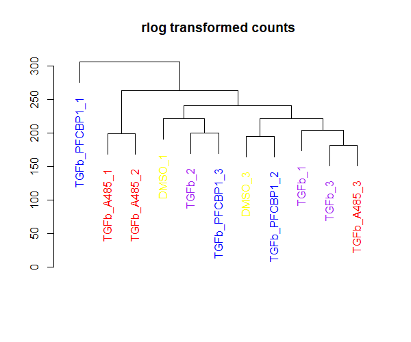

### PCA

Principle component analysis depicts sample similarity and allows us to visualize quality of sample identity. Principle components were acquired from using the top 1000 genes with the highest correlation coeffecients.

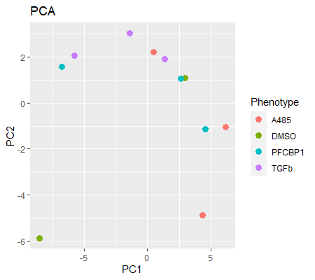

### SVA

Here would be a description and analysis utilizing surrogate variable analysis. This attempts to reduce influence from batch effects and other technical errors but would significantly reduce the gene expression output in this study. Rather than SVA, it might be beneficial to include replicant # in the deisgn model of DESeq2. This would allow DESeq2 to attempt reducing gene expression influence from replicate differences.

## OUTLIER DETECTION

Considering the alignment score, PCA plot, total library sizes, and pairwise replicate correlations it has been deduced that sample DMSO #2 is of insufficient quality to be adequately used in downstream analysis and must be removed.

Unfortunately, this has a negative effect on the analysis. Only two negative controls remain which is limiting of the true outcome of significantly differentially expressed genes. Additional data would be required for publication.

Any additional data to combine with this data must be examined for quality as well. In theory a replication study should be similar to the current one but because of the gap of time between procedures and additional technical factors it is possible that the samples may differ by batch errors and not by phenotype.

# **ANALYSIS REPORT**

## OVERVIEW

The data and results are stored on the analysist’s local PC and CSPH biostats server.

DMSO is of insufficant library size and has been removed.

11 samples total.

| DMSO | TGFb | TGFb + PFCBP1 | TGFb + A485 |
| --- | --- | --- | --- |
| 2 | 3 | 3 | 3 |

## STATISTICAL SUMMARY

Methods used for differential expression analysis incorporate the modern methods used in the R statistical software packages DEseq2. This includes rlog transformation ( multistep geometric averaging) and Wald hypothesis testing which assumes the expression data follows a negative binomial distribution.

## DIFFERENTIAL EXPRESSION ANALYSIS

27513 genes are included in the final counts matrix

The DESeq2 Model were Phenotype represents the 4 phenotype treatments :

> design = ~Phenotype

P value < .05 and log2 Fold Change > |1| were used for genes to be considered signficanty differentially expressed.

### venn diagram

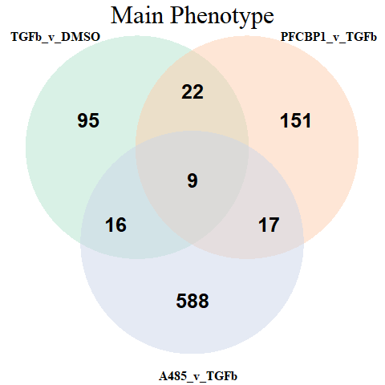

### DE results

##### RESULTS

[interactive chart not shown]

##### VOLCANO

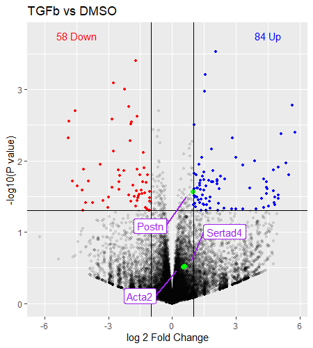

##### RESULTS

[interactive chart not shown]

##### VOLCANO

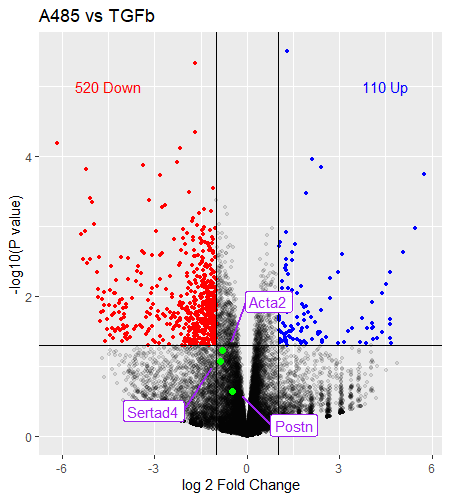

##### RESULTS

[interactive chart not shown]

##### VOLCANO

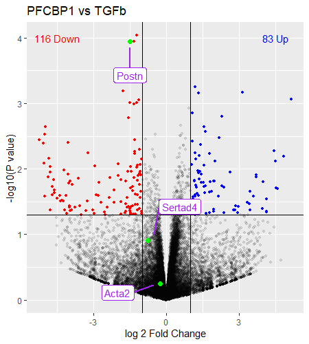

### VOLCANO PLOTS

Here are the volcano plots together so that you can quickly visualize differences.

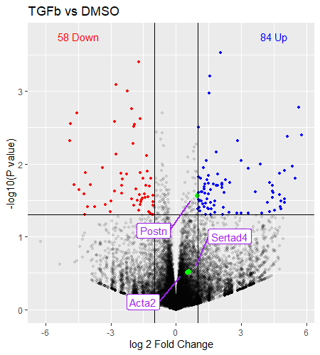

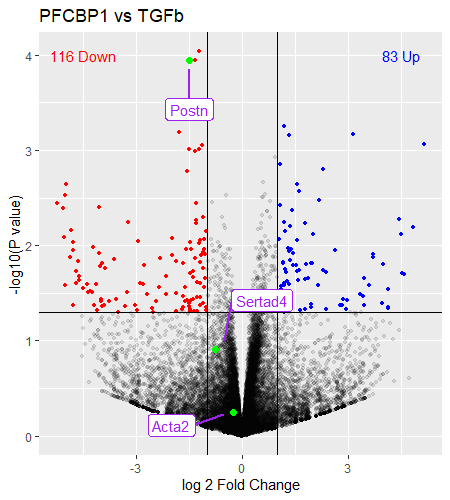

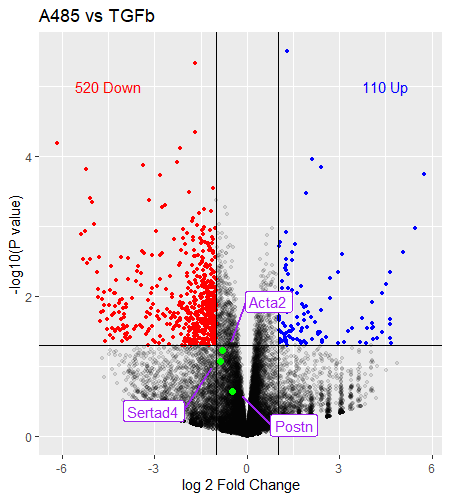

### Heatmap

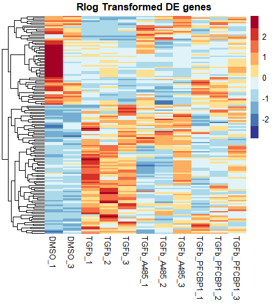

## ENRICHMENT ANALYSIS

### GOrilla

The genesets associated with each domain are attributed to select genes. The list of genes for each pathway can be acquired upon request until additions are made.

#### Process

[interactive chart not shown]

#### Function

[interactive chart not shown]

#### Componenent

[interactive chart not shown]

#### **TGFb + A485 vs TGFb**

#### Process

[interactive chart not shown]

#### Function

[interactive chart not shown]

#### Componenent

[interactive chart not shown]

#### **TGFb + PFCBP1 vs TGFb**

#### Process

[interactive chart not shown]

#### Function

[interactive chart not shown]

#### Componenent

[interactive chart not shown]

## FUTURE WORK

Future works suggests incorporating new data to combine samples for higher statistical power or perhaps redo analysis for higher quality samples separately.

Additional Gene ontology analysis is under development as well.

## References

#### Adapter Trimming

Bushnell, B. “BBMap.” SourceForge, 2020, sourceforge.net/projects/bbmap/.

#### Alignment mapping tool

Dobin A, Davis CA, Schlesinger F, Drenkow J, Zaleski C, Jha S, Batut P, Chaisson M, Gingeras TR. STAR: ultrafast universal RNA-seq aligner. Bioinformatics. 2013 Jan 1;29(1):15-21. doi: 10.1093/bioinformatics/bts635

#### Abundance Quantifying tool

Liao Y, Smyth GK and Shi W. featureCounts: an efficient general-purpose program for assigning sequence reads to genomic features. Bioinformatics, 30(7):923-30, 2014

#### Differential expresssion package

Love, M.I., Huber, W., Anders, S. Moderated estimation of fold change and dispersion for RNA-seq data with DESeq2 Genome Biology 15(12):550 (2014)

#### GOrilla Software